# Scatter Plots and Correlation Analysis

Social and Cultural Analytics (7AAVBCS5)

Dr Mark J. Hill · mark.j.hill@kcl.ac.uk

2026-11-16

## Lecture Plan

- **Part I: Introduction to Bivariate Analysis**
- **Part II: Scatter Plots**
- **Part III: Correlations**
- **Part IV: Creating Scatter Plots**
- **Part V: Thinking about causes** *(extra if time)*
- **Part VI: Live Coding**

**Key Learning Outcomes**

By the end of this week you will be able to:

- Explore the relationship between two numeric variables
- Read a scatter plot and describe the pattern
- Calculate and interpret Pearson and Spearman correlations
- Choose between them, and justify the choice
- Encode a third variable with size, colour or shape
- Explain why correlation is not causation

## Review

- Data frames, selecting, filtering, missing data
- Categories, frequency tables, crosstabs, `groupby`
- Counts versus percentages
- Bar plots, distributions, histograms

**This week:** two numeric variables at once

# Part I: Bivariate Analysis

## Bivariate analysis

Bivariate analysis examines the relationship between two numeric/ordinal variables — how they might be connected or influence each other.

Moving beyond describing single variables to understanding how things **relate**.

**Key questions**

- Do the variables change together?
- When one increases, does the other increase or decrease?
- How strong is the relationship?
- Is there a pattern we can describe?

**How we assess**

1. **Scatter plots** — each point is one observation; position shows both values; the pattern reveals the relationship, or its absence
2. **Measures of correlation** — Pearson, Spearman, regression models

## Why relationships matter

In culture, phenomena rarely exist in isolation:

- Film budget ↔︎ box office revenue
- Social media engagement ↔︎ time of day
- Text length ↔︎ reading difficulty
- Historical period ↔︎ genre popularity

Why the double-headed arrow? **Collinearity** — relationships can work in either direction, or both. Statistics cannot tell you which. That judgement is yours as a researcher.

# Part II: Scatter Plots

## Anatomy of a scatter plot

- **X-axis:** independent / predictor variable
- **Y-axis:** dependent / response variable
- **Each point:** one observation
- **Pattern:** reveals the relationship

**When to use**

- To inspect a potential relationship between two numeric variables
- To verify statistical analyses — correlation, linear regression

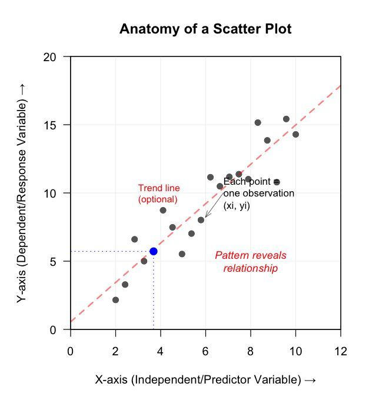

## Types of relationships

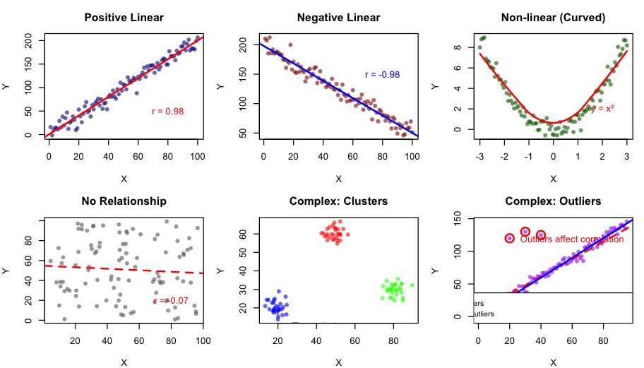

## Why visualise, when we can measure?

Because two datasets can have identical statistics and completely different shapes.

## Anscombe’s quartet

```python
import pandas as pd

x1 = [10, 8, 13, 9, 11, 14, 6, 4, 12, 7, 5]
x4 = [8] * 8 + [19, 8, 8]
sets = {
    "I":   (x1, [8.04, 6.95, 7.58, 8.81, 8.33, 9.96, 7.24, 4.26, 10.84, 4.82, 5.68]),
    "II":  (x1, [9.14, 8.14, 8.74, 8.77, 9.26, 8.10, 6.13, 3.10, 9.13, 7.26, 4.74]),
    "III": (x1, [7.46, 6.77, 12.74, 7.11, 7.81, 8.84, 6.08, 5.39, 8.15, 6.42, 5.73]),
    "IV":  (x4, [6.58, 5.76, 7.71, 8.84, 8.47, 7.04, 5.25, 5.56, 12.50, 7.91, 6.89]),
}

pd.DataFrame(
    [{"set": k, "mean x": round(pd.Series(x).mean(), 2),
      "mean y": round(pd.Series(y).mean(), 2),
      "sd y": round(pd.Series(y).std(), 2),
      "r": round(pd.Series(x).corr(pd.Series(y)), 3)}
     for k, (x, y) in sets.items()]
)
```

|  | set | mean x | mean y | sd y | r |
| --- | --- | --- | --- | --- | --- |
| 0 | I | 9.0 | 7.5 | 2.03 | 0.816 |
| 1 | II | 9.0 | 7.5 | 2.03 | 0.816 |
| 2 | III | 9.0 | 7.5 | 2.03 | 0.816 |
| 3 | IV | 9.0 | 7.5 | 2.03 | 0.817 |

## The same four datasets, plotted

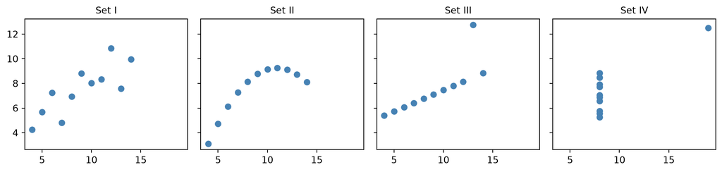

```python
import matplotlib.pyplot as plt

fig, axes = plt.subplots(1, 4, figsize=(11, 2.7), sharex=True, sharey=True)
for ax, (name, (x, y)) in zip(axes, sets.items()):
    ax.scatter(x, y, color="steelblue")
    ax.set_title(f"Set {name}", fontsize=10)
plt.tight_layout()
plt.show()
```

Same mean. Same standard deviation. Same correlation. Four different stories.

## Lesson: visualise as part of analysing

EDA is not a preliminary step you skip when busy.

# Part III: Correlations

## What is correlation?

Correlation measures two things:

1. **Strength** of association between two variables
2. **Direction** of the relationship

Coefficients range from **−1 to +1**:

- ±1 = perfect association
- ~0 = no relationship
- > 0 = positive · < 0 = negative

Correlation ≠ Causation

*OED, “coefficient”:* “Cooperating to produce a result.” “A joint agent or factor in producing an effect or result.”

## Interpreting strength

| r |  | Interpretation |
| --- | --- | --- |
| 0.8 to 1 | −0.8 to −1 | Very strong |
| 0.6 to 0.8 | −0.6 to −0.8 | Strong |
| 0.4 to 0.6 | −0.4 to −0.6 | Moderate |
| 0.2 to 0.4 | −0.2 to −0.4 | Weak |
| 0 to 0.2 | 0 to −0.2 | Very weak / none |

Note: the importance of an r value differs depending on the data. In some fields 0.3 is a major finding; in others 0.8 is unremarkable.

## Pearson correlation

Measures the strength of a **straight-line** relationship.

- Uses your actual data values
- Best for “as X increases, Y increases in a straight line”

**Strength:** very precise when the relationship is linear

**Weaknesses:** one extreme value can throw it off badly; misses curves

**When to use**

- Both variables continuous
- The scatter plot looks roughly like a straight line
- No wild outliers

If you could draw a straight line through it, use Pearson.

## Spearman correlation

Measures whether two variables **consistently move together**.

- Converts data to **rankings** first
- Captures any consistent pattern, even curves

**Strengths:** handles curves; outliers do not upset it; works with ordered categories such as Likert scales

**Weakness:** slightly less powerful than Pearson when the relationship really is linear

**When to use**

- Ordinal data (rankings, survey scales)
- Curved but consistent relationships
- Outliers present
- Unsure about the distribution

Consistent movement, but curvy or with outliers → Spearman.

## What do we mean by rankings?

| Original X | Ranked X | Original Y | Ranked Y |
| --- | --- | --- | --- |
| 1 | 1 | 2 | 1 |
| 3 | 2 | 5 | 2 |
| 7 | 3 | 10 | 3 |
| 10 | 4 | 18 | 4 |
| 12 | 5 | 30 | 5 |
| 14 | 6 | 35 | 6 |
| 15 | 7 | 45 | 7 |

Spearman correlates the **ranks**, not the values. So it does not care how far apart the numbers are — only about their order.

## Correlation in Python

```python
dawtry = pd.read_csv("../../data/DawtryEtAl2015.csv")

pair = dawtry[["Household_Income", "Social_Circle_Mean_Income"]].dropna()
print("n =", len(pair))
print("Pearson :", round(pair["Household_Income"].corr(pair["Social_Circle_Mean_Income"]), 3))
print("Spearman:", round(pair["Household_Income"].corr(pair["Social_Circle_Mean_Income"],
                                                       method="spearman"), 3))
```

```
n = 301
Pearson : 0.475
Spearman: 0.405
```

## When Pearson and Spearman disagree

```python
pair = dawtry[["Household_Income", "fairness"]].dropna()
print("Pearson :", round(pair["Household_Income"].corr(pair["fairness"]), 3))
print("Spearman:", round(pair["Household_Income"].corr(pair["fairness"], method="spearman"), 3))
```

```
Pearson : 0.174
Spearman: 0.234
```

Pearson says 0.174 — very weak. Spearman says 0.234 — weak but noticeably stronger. Why?

## A real correlation, and a real null

```python
for a, b in [("Political_Preference", "redist1"), ("age", "Household_Income")]:
    s = dawtry[[a, b]].dropna()
    print(f"{a:22} x {b:18} n={len(s):3}  r = {s[a].corr(s[b]):+.3f}")
```

```
Political_Preference   x redist1            n=301  r = -0.520
age                    x Household_Income   n=300  r = +0.018
```

## Bad correlations

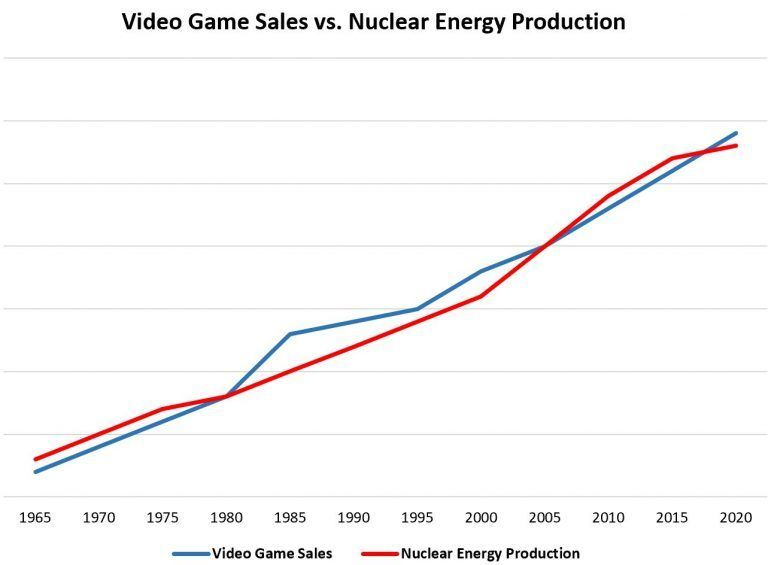

# Part IV: Creating scatter plots

## A basic scatter plot

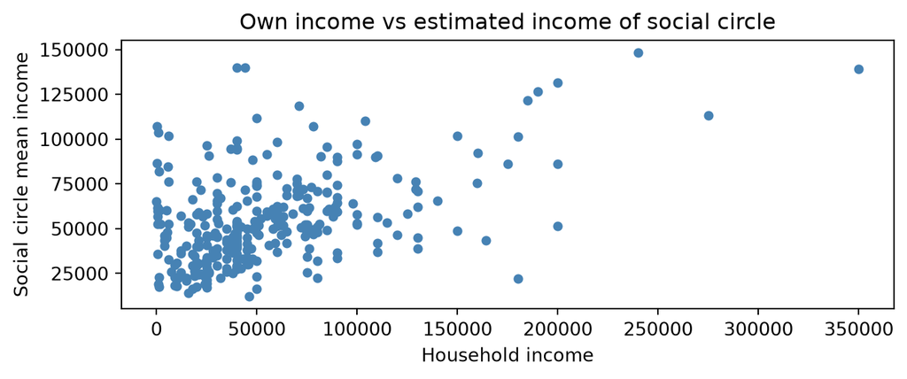

```python
fig, ax = plt.subplots(figsize=(7, 3))
ax.scatter(dawtry["Household_Income"], dawtry["Social_Circle_Mean_Income"],
           color="steelblue", s=18)
ax.set_title("Own income vs estimated income of social circle")
ax.set_xlabel("Household income")
ax.set_ylabel("Social circle mean income")
plt.tight_layout()
plt.show()
```

## Visual variables (Bertin’s semiology)

| Visual variable | Best for | Example |
| --- | --- | --- |
| Position (x, y) | primary variables | the main relationship |
| Size | third numeric variable | population, importance |
| Colour (hue) | categories | groups, types |
| Colour (saturation) | continuous values | intensity, amount |
| Shape | categories | different types |
| Transparency / jitter | overlapping points | density |

Every visual element should encode information.

## A third variable: size and transparency

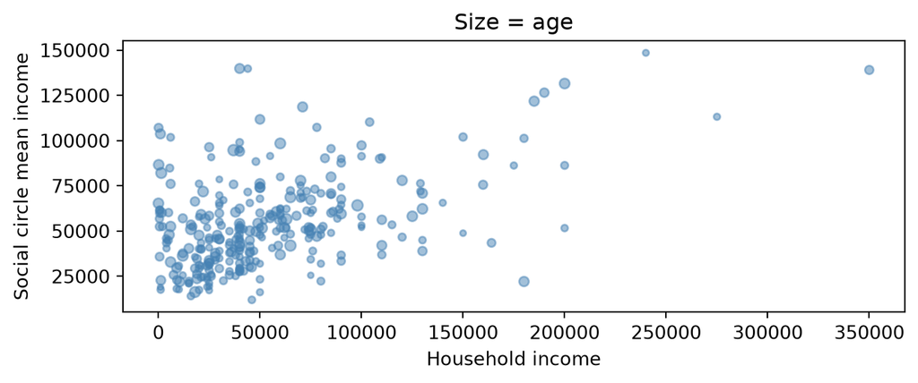

```python
sub = dawtry[["Household_Income", "Social_Circle_Mean_Income", "age"]].dropna()

fig, ax = plt.subplots(figsize=(7, 3))
ax.scatter(sub["Household_Income"], sub["Social_Circle_Mean_Income"],
           s=sub["age"] / 2, alpha=0.5, color="steelblue")
ax.set_xlabel("Household income")
ax.set_ylabel("Social circle mean income")
ax.set_title("Size = age")
plt.tight_layout()
plt.show()
```

## A third variable: colour by category

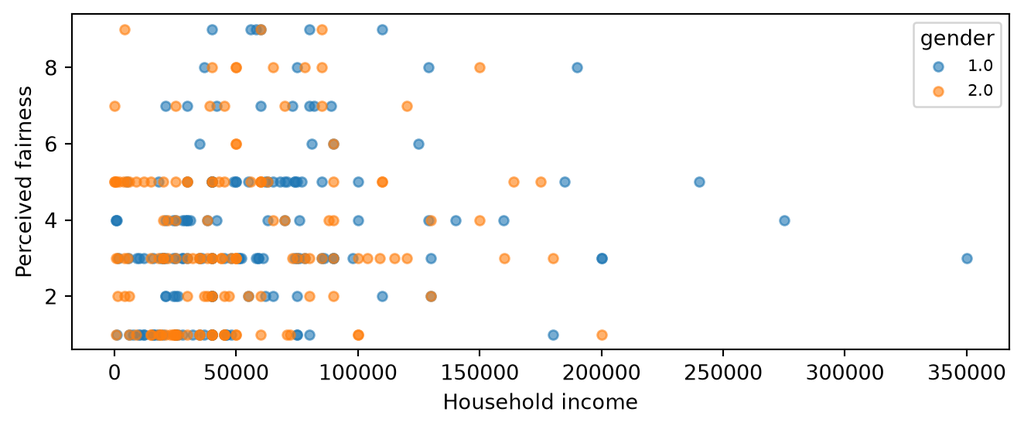

```python
sub = dawtry[["Household_Income", "fairness", "gender"]].dropna()

fig, ax = plt.subplots(figsize=(7, 3))
for name, grp in sub.groupby("gender"):
    ax.scatter(grp["Household_Income"], grp["fairness"], label=str(name), alpha=0.6, s=20)
ax.set_xlabel("Household income")
ax.set_ylabel("Perceived fairness")
ax.legend(title="gender", fontsize=8)
plt.tight_layout()
plt.show()
```

# Part V: Thinking about causes

*Extra, if time*

## Types of patterns

**1. Differences between groups**

**2. Social change**

**3. Cross-national comparisons**

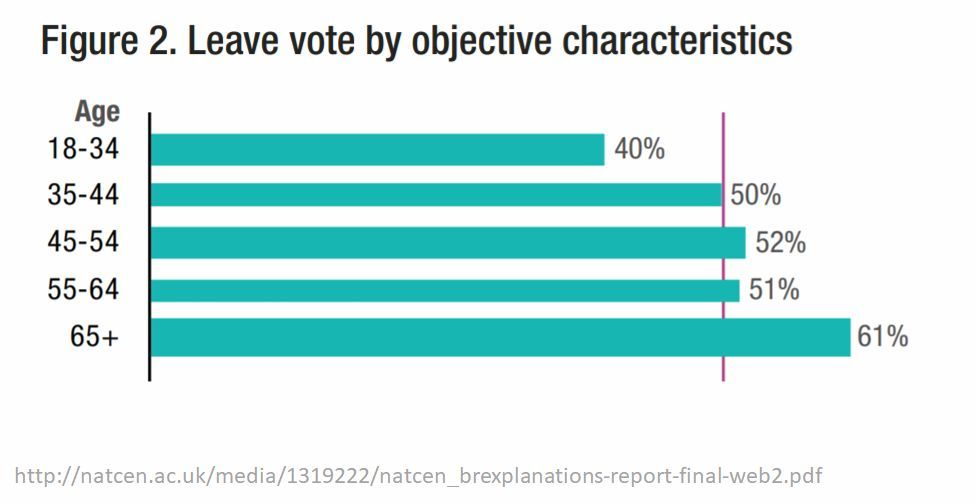

## Causal inference

```
Exposure to hateful or toxic          Negative attitudes toward
content on a platform         ──────▶ minority groups
                        hypothetical causal relationship
```

**Language:** the first is the *independent variable* (IV), also called causal, explanatory, or predictor. The second is the *dependent variable* (DV), also outcome, symptom, or response.

## Counterfactuals

To claim the first causes the second, you need to know what would have happened **without** it.

```
Exposure    ──────▶  Negative attitudes
No exposure ──────▶  Negative attitudes?      ← the counterfactual
```

You cannot observe both for the same person. That is the fundamental problem of causal inference.

## Confounding variables

A working counterfactual is not always enough.

```
Exposure ──────▶ Negative attitudes
     ▲                    ▲
     └──── Confounders ───┘

    pre-existing beliefs · news consumption
    offline influence · algorithmic influence
```

Hill, “Contextual Analytics”, §5.4–5.5 — the mechanisms that remain unrepresented must not be silently absorbed into the interpretation.

# Part VI: Live Coding

## Live coding

1. Scatter plot of two variables from the survey data
2. Pearson and Spearman, and why they differ here
3. A third variable by size, then by colour
4. A null result, and how to report it
5. Save the figure

## Before next week

1. Complete `w08_worksheet.ipynb` in the workshop
2. Read Hill, “Contextual Analytics”, §5.4–5.5

**Note**

The quiz in next week’s lecture covers **this week’s** material.